# rbasic_20190909_141_choi

## 3.10 Sorting

### 3.10.1 `sort`

The funtction `sort` sorts a vector in increasing order. The largest number of gun murders:

```r
library(dslabs)
data("murders")
sort(murders$total)
```

```
 [1]    2    4    5    5    7    8   11   12   12   16   19   21   22   27   32   36
[17]   38   53   63   65   67   84   93   93   97   97   99  111  116  118  120  135
[33]  142  207  219  232  246  250  286  293  310  321  351  364  376  413  457  517
[49]  669  805 1257
```

This does not give us unformation about which states have shich murder totals.

### 3.10.2 `order`

The funtion `order` is closer to what we want. It takes a vector as input and returns the vector of indexes that sorts the input vector.

```r
x <- c(31, 4, 15, 92, 65)
sort(x)
```

```
[1]  4 15 31 65 92
```

The funtion `order` returns the index that sorts input vector, same output as that returned by `sort(x)`:

```r
index <- order(x)
x[index]
```

```
[1]  4 15 31 65 92
```

```r
x
```

```
[1] 31  4 15 92 65
```

```r
order(x)
```

```
[1] 2 3 1 5 4
```

First, remember that the entries of vectors you access with $ follow the same order as the rows in the table.

```r
murders$state[1:10]
```

```
 [1] "Alabama"              "Alaska"               "Arizona"
 [4] "Arkansas"             "California"           "Colorado"
 [7] "Connecticut"          "Delaware"             "District of Columbia"
[10] "Florida"
```

```r
murders$abb[1:10]
```

```
 [1] "AL" "AK" "AZ" "AR" "CA" "CO" "CT" "DE" "DC" "FL"
```

This means we can order the state names by their total murders. We first obtain the index that orders the vectors according to murder totals and then index the state names vector:

```r
ind <- order(murders$total)
murders$abb[ind]
```

```
 [1] "VT" "ND" "NH" "WY" "HI" "SD" "ME" "ID" "MT" "RI" "AK" "IA" "UT" "WV" "NE" "OR"
[17] "DE" "MN" "KS" "CO" "NM" "NV" "AR" "WA" "CT" "WI" "DC" "OK" "KY" "MA" "MS" "AL"
[33] "IN" "SC" "TN" "AZ" "NJ" "VA" "NC" "MD" "OH" "MO" "LA" "IL" "GA" "MI" "PA" "NY"
[49] "FL" "TX" "CA"
```

### 3.10.3 `max` and `which.max`

For the largest value, use `max`:

```r
max(murders$total)
```

```
[1] 1257
```

for the index of the largest value, use `which.max`:

```r
i_max <- which.max(murders$total)
murders$state[i_max]
```

```
[1] "California"
```

For the minimum, we can use `min` and `which.min` in the same way.

### 3.10.4 `rank`

```r
x <- c(31, 4, 15, 92, 65)
rank(x)
```

```
[1] 3 1 2 5 4
```

### 3.10.5 Beware of recycling

So if the vectors don’t match in length, it is natural to assume that we should get an error.

```r
x <- c(1,2,3)
y <- c(10, 20, 30, 40, 50, 60, 70)
x+y
```

```
longer object length is not a multiple of shorter object length
```

```
[1] 11 22 33 41 52 63 71
```

For the output, R has recycled the numbers in `x.` Notice the last digit of numbers in the output.

## 3.11 Exercise

For these exercises we will use the US murders dataset. Make sure you load it prior to starting.

```r
library(dslabs)
data("murders")
```

1. Use the `$` operator to access the population size data and store it as the object `pop`. Then use the `sort` function to redefine `pop` so that it is sorted. Finally, use the `[` operator to report the smallest population size.

```r
pop <- murders$population
pop <- sort(pop)
pop[1]
```

```
[1] 563626
```

2. Now instead of the smallest population size, find the index of the entry with the smallest population size. Hint: use `order` instead of `sort`.

```r
murders$state[order(murders$population)][1]
```

```
[1] "Wyoming"
```

3. We can actually perform the same operation as in the previous exercise using the function `which.min`. Write one line of code that does this.

```r
murders$state[which.min(pop)]
```

```
[1] "Alabama"
```

4. Now we know how small the smallest state is and we know which row represents it. Which state is it? Define a variable `states` to be the state names from the `murders` data frame. Report the name of the state with the smallest population.

```r
states <- order(murders$state)
min(murders$state[states])
```

```
[1] "Alabama"
```

5. You can create a data frame using the `data.frame` function. Here is a quick example:

```r
temp <- c(35, 88, 42, 84, 81, 30)
city <- c("Beijing", "Lagos", "Paris", "Rio de Janeiro", "San Juan", "Toronto")
city_temps <- data.frame(name = city, temperature = temp)
```

Use the `rank` function to determine the population rank of each state from smallest population size to biggest. Save these `ranks` in an object called ranks, then create a data frame with the state name and its rank. Call the data frame `my_df`.

```r
ranks <- rank(murders$population)
my_df <- data.frame(name = murders$state, rank = ranks)
my_df
```

| name | rank |
| --- | --- |
| Alabama | 29 |
| Alaska | 5 |
| Arizona | 36 |
| Arkansas | 20 |
| California | 51 |
| Colorado | 30 |
| Connecticut | 23 |
| Delaware | 7 |
| District of Columbia | 2 |
| Florida | 49 |

[output cut: 41 more lines]

6. Repeat the previous exercise, but this time order `my_df` so that the states are ordered from least populous to most populous. Hint: create an object `ind` that stores the indexes needed to order the population values. Then use the bracket operator `[` to re-order each column in the data frame.

```r
ind <- order(my_df$rank)
my_df$name[ind]
```

```
 [1] "Wyoming"              "District of Columbia"
 [3] "Vermont"              "North Dakota"
 [5] "Alaska"               "South Dakota"
 [7] "Delaware"             "Montana"
 [9] "Rhode Island"         "New Hampshire"
[11] "Maine"                "Hawaii"
[13] "Idaho"                "Nebraska"
[15] "West Virginia"        "New Mexico"
[17] "Nevada"               "Utah"
[19] "Kansas"               "Arkansas"
[21] "Mississippi"          "Iowa"
[23] "Connecticut"          "Oklahoma"
[25] "Oregon"               "Kentucky"
[27] "Louisiana"            "South Carolina"
[29] "Alabama"              "Colorado"
[31] "Minnesota"            "Wisconsin"
[33] "Maryland"             "Missouri"
[35] "Tennessee"            "Arizona"
[37] "Indiana"              "Massachusetts"
[39] "Washington"           "Virginia"
[41] "New Jersey"           "North Carolina"
[43] "Michigan"             "Georgia"
[45] "Ohio"                 "Pennsylvania"
[47] "Illinois"             "New York"
[49] "Florida"              "Texas"
[51] "California"
```

7. The `na_example` vector represents a series of counts. You can quickly examine the object using:

```r
data("na_example")
str(na_example)
```

```
 int [1:1000] 2 1 3 2 1 3 1 4 3 2 ...
```

However, when we compute the average with the function mean, we obtain an NA:

```r
mean(na_example)
```

```
[1] NA
```

The `is.na` function returns a logical vector that tells us which entries are `NA`. Assign this logical vector to an object called `ind` and determine how many `NA`s does `na_example` have.

```r
ind <- is.na(na_example)
length(ind)
```

```
[1] 1000
```

8. Now compute the average again, but only for the entries that are not `NA`. Hint: remember the `!` operator.

```r
mean(na_example[!ind])
```

```
[1] 2.301754
```

## 3.12 Vector arithmetics

We can quickly confirm that California indeed has the largest population:

```r
library(dslabs)
data("murders")
murders$state[which.max(murders$population)]
```

```
[1] "California"
```

### 3.12.1 Rescaling a vector

In R, arithmetic operations on vectors occur element-wise. For a quick example, suppose we have height in inches:

```r
inches <- c(69, 62, 66, 70, 70, 73, 67, 73, 67, 70)
```

and want to convert to centimeters. Notice what happens when we multiply inches by 2.54

```r
inches * 2.54
```

```
 [1] 175.26 157.48 167.64 177.80 177.80 185.42 170.18
 [8] 185.42 170.18 177.80
```

If for each entry we want to compute how many inches taller or shorter than 69 inches, the average height for males, we can subtract it from every entry like this:

```r
inches - 69
```

```
 [1]  0 -7 -3  1  1  4 -2  4 -2  1
```

3.12.2 Two vectors

```r
murder_rate <- murders$total / murders$population * 100000
murders$state[order(murder_rate)]
```

```
 [1] "Vermont"              "New Hampshire"
 [3] "Hawaii"               "North Dakota"
 [5] "Iowa"                 "Idaho"
 [7] "Utah"                 "Maine"
 [9] "Wyoming"              "Oregon"
[11] "South Dakota"         "Minnesota"
[13] "Montana"              "Colorado"
[15] "Washington"           "West Virginia"
[17] "Rhode Island"         "Wisconsin"
[19] "Nebraska"             "Massachusetts"
[21] "Indiana"              "Kansas"
[23] "New York"             "Kentucky"
[25] "Alaska"               "Ohio"
[27] "Connecticut"          "New Jersey"
[29] "Alabama"              "Illinois"
[31] "Oklahoma"             "North Carolina"
[33] "Nevada"               "Virginia"
[35] "Arkansas"             "Texas"
[37] "New Mexico"           "California"
[39] "Florida"              "Tennessee"
[41] "Pennsylvania"         "Arizona"
[43] "Georgia"              "Mississippi"
[45] "Michigan"             "Delaware"
[47] "South Carolina"       "Maryland"
[49] "Missouri"             "Louisiana"
[51] "District of Columbia"
```

## 3.13 Exercises

1. Previously we created this data frame:

```r
temp <- c(35, 88, 42, 84, 81, 30)
city <- c("Beijing", "Lagos", "Paris", "Rio de Janeiro", "San Juan", "Toronto")
city_temps <- data.frame(name = city, temperature = temp)
```

Remake the data frame using the code above, but add a line that converts the temperature from Fahrenheit to Celsius. The conversion is C = 5/9 * (F-32)

```r
temp_C = 5/9 * (temp-32)
city_temps <-data.frame(name = city, temperature_F = temp, temperature_C = temp_C)
city_temps
```

| name | temperature_F | temperature_C |
| --- | --- | --- |
| Beijing | 35 | 1.666667 |
| Lagos | 88 | 31.111111 |
| Paris | 42 | 5.555556 |
| Rio de Janeiro | 84 | 28.888889 |
| San Juan | 81 | 27.222222 |
| Toronto | 30 | -1.111111 |

```r
x <- seq(1:100)
sum(1/x^2)
```

```
[1] 1.634984
```

3. Compute the per 100,000 murder rate for each state and store it in the object murder_rate. Then compute the average murder rate for the US using the function mean. What is the average?

```r
murder_rate <- murders$total/murders$population * 100000
mean(murder_rate)
```

```
[1] 2.779125
```

## 3.14 Indexing

We can ubset a vector based on properties of another vector.

### 3.14.1 Subsetting with logicals

```r
murder_rate <- murders$total / murders$population * 100000
```

we can use logicals to index vectors. If we compare a vector to a single number, it actually performs the test for each entry. The following is an example related to the question above:

```r
ind <- murder_rate <= 0.71
ind
```

```
 [1] FALSE FALSE FALSE FALSE FALSE FALSE FALSE FALSE
 [9] FALSE FALSE FALSE  TRUE FALSE FALSE FALSE  TRUE
[17] FALSE FALSE FALSE FALSE FALSE FALSE FALSE FALSE
[25] FALSE FALSE FALSE FALSE FALSE  TRUE FALSE FALSE
[33] FALSE FALSE  TRUE FALSE FALSE FALSE FALSE FALSE
[41] FALSE FALSE FALSE FALSE FALSE  TRUE FALSE FALSE
[49] FALSE FALSE FALSE
```

We get back a logical vector with TRUE for each entry smaller than or equal to 0.71. We can leverage the fact that vectors can be indexed with logicals.

```r
murders$state[ind]
```

```
[1] "Hawaii"        "Iowa"          "New Hampshire"
[4] "North Dakota"  "Vermont"
```

```r
sum(ind)
```

```
[1] 5
```

### 3.14.2 Logical operators

Here we can use the logical operator and, which in R is represented with &. This operation results in TRUE only when both logicals are TRUE. To see this, consider this example:

```r
TRUE & TRUE
```

```
[1] TRUE
```

```r
TRUE & FALSE
```

```
[1] FALSE
```

```r
FALSE & FALSE
```

```
[1] FALSE
```

we can use the & to get a vector of logicals that tells us which states satisfy both conditions:

```r
west <- murders$region == "West"
safe <- murder_rate <= 1
ind <- safe & west
murders$state[ind]
```

```
[1] "Hawaii"  "Idaho"   "Oregon"  "Utah"    "Wyoming"
```

### 3.14.3 `which`

The function which tells us which entries of a logical vector are TRUE. So we can type:

```r
ind <- which(murders$state == "California")
murder_rate[ind]
```

```
[1] 3.374138
```

### 3.14.4 `match`

If we want to find out the murder rates for several states, we can use the function `match`. This function tells us which indexes of a second vector match each of the entries of a first vector:

```r
ind <- match(c("New York", "Florida", "Texas"), murders$state)
ind
```

```
[1] 33 10 44
```

We can look at the murder rates:

```r
murder_rate[ind]
```

```
[1] 2.667960 3.398069 3.201360
```

### 3.14.5 `%in%`

If rather than an index we want a logical that tells us whether or not each element of a first vector is in a second, we can use the function %in%.

```r
c("Boston", "Dakota", "Washington") %in% murders$state
```

```
[1] FALSE FALSE  TRUE
```

There is a connection between match and %in% through which. To see this, notice that the following two lines produce the same index (although in different order):

```r
match(c("New York", "Florida", "Texas"), murders$state)
```

```
[1] 33 10 44
```

```r
which(murders$state%in%c("New York", "Florida", "Texas"))
```

```
[1] 10 33 44
```

## 3.15 Exercises

1. Compute the per 100,000 murder rate for each state and store it in an object called murder_rate. Then use logical operators to create a logical vector named low that tells us which entries of murder_rate are lower than 1.

```r
murder_rate <- murders$total/murders$population * 100000
low <- murder_rate < 1
low
```

```
 [1] FALSE FALSE FALSE FALSE FALSE FALSE FALSE FALSE FALSE
[10] FALSE FALSE  TRUE  TRUE FALSE FALSE  TRUE FALSE FALSE
[19] FALSE  TRUE FALSE FALSE FALSE  TRUE FALSE FALSE FALSE
[28] FALSE FALSE  TRUE FALSE FALSE FALSE FALSE  TRUE FALSE
[37] FALSE  TRUE FALSE FALSE FALSE  TRUE FALSE FALSE  TRUE
[46]  TRUE FALSE FALSE FALSE FALSE  TRUE
```

2. Now use the results from the previous exercise and the function which to determine the indices of murder_rate associated with values lower than 1.

```r
ind <- which(low)
murder_rate[ind]
```

```
 [1] 0.5145920 0.7655102 0.6893484 0.8280881 0.9992600
 [6] 0.3798036 0.5947151 0.9396843 0.9825837 0.7959810
[11] 0.3196211 0.8871131
```

3. Use the results from the previous exercise to report the names of the states with murder rates lower than 1.

```r
murders$state[low]
```

```
 [1] "Hawaii"        "Idaho"         "Iowa"
 [4] "Maine"         "Minnesota"     "New Hampshire"
 [7] "North Dakota"  "Oregon"        "South Dakota"
[10] "Utah"          "Vermont"       "Wyoming"
```

4. Now extend the code from exercise 2 and 3 to report the states in the Northeast with murder rates lower than 1. Hint: use the previously defined logical vector low and the logical operator &.

```r
Northeast <- murders$region == "Northeast"
low <- murder_rate < 1
ind <- Northeast & low
murders$state[ind]
```

```
[1] "Maine"         "New Hampshire" "Vermont"
```

5. In a previous exercise we computed the murder rate for each state and the average of these numbers. How many states are below the average?

```r
x <- murder_rate < mean(murder_rate)
sum(x)
```

```
[1] 27
```

6. Use the match function to identify the states with abbreviations AK, MI, and IA. Hint: start by defining an index of the entries of murders$abb that match the three abbreviations, then use the [ operator to extract the states.

```r
ind <- match(c("AK", "MI", "IA"), murders$abb)
murders$state[ind]
```

```
[1] "Alaska"   "Michigan" "Iowa"
```

7. Use the %in% operator to create a logical vector that answers the question: which of the following are actual abbreviations: MA, ME, MI, MO, MU ?

```r
c("MA", "ME", "MI", "MO", "MU") %in% murders$abb
```

```
[1]  TRUE  TRUE  TRUE  TRUE FALSE
```

8. Extend the code you used in exercise 7 to report the one entry that is not an actual abbreviation. Hint: use the ! operator, which turns FALSE into TRUE and vice versa, then which to obtain an index.

```r
true_abb <- !c("MA", "ME", "MI", "MO", "MU") %in% murders$abb
ind <- which(true_abb)
ind
```

```
[1] 5
```

## 3.16 Basic plots

### 3.16.1 `plot

The plot function can be used to make scatterplots. Here is a plot of total murders versus population.

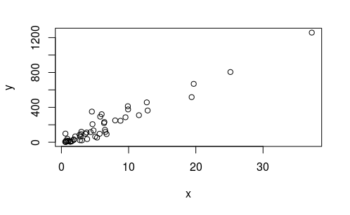

```r
x <- murders$population / 10^6
y <- murders$total

plot(x, y)
```

For a quick plot that avoids accessing variables twice, we can use the `with` function:

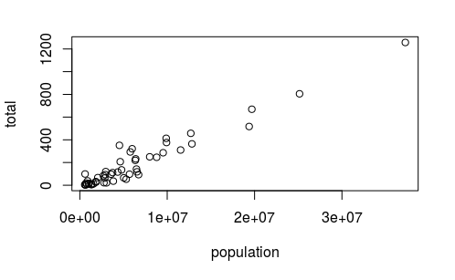

```r
with(murders, plot(population, total))
```

The function `with` lets us use the `murders` column names in the `plot` function.

### 3.16.2 `hist`

We can make a histogram of our murder rates by simply typing:

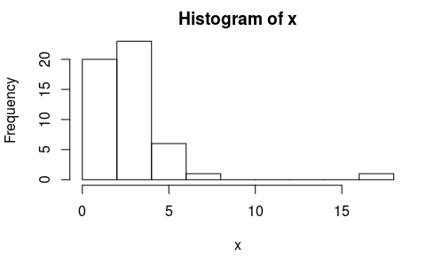

```r
x <- with(murders, total / population * 100000)
hist(x)
```

We can see that there is a wide range of values with most of them between 2 and 3 and one very extreme case with a murder rate of more than 15:

```r
murders$state[which.max(x)]
```

```
[1] "District of Columbia"
```

### 3.16 3 `boxplot`

Boxplot provide a more terse summary than histograms, but they are easier to stack with other boxplots.

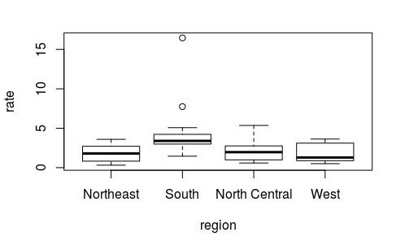

```r
murders$rate <- with(murders, total / population * 100000)
boxplot(rate~region, data = murders)
```

### 3.16.4 `image`

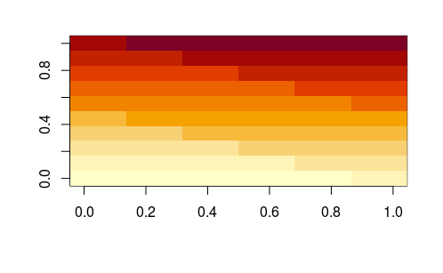

```r
x <- matrix(1:120, 12, 10)
image(x)
```

## 3.17 Exercises

1. We made a plot of total murders versus population and noted a strong relationship. Not surprisingly, states with larger populations had more murders.

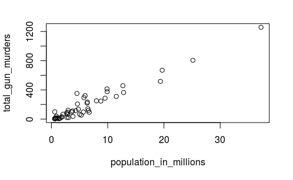

```r
population_in_millions <- murders$population/10^6
total_gun_murders <- murders$total
plot(population_in_millions, total_gun_murders)
```

Keep in mind that many states have populations below 5 million and are bunched up. We may gain further insights from making this plot in the log scale. Transform the variables using the log10 transformation and then plot them.

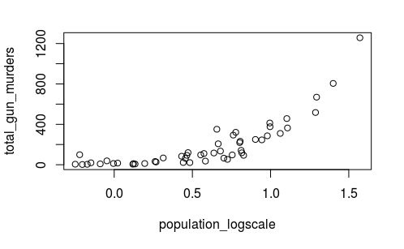

```r
population_logscale <- log10( murders$population/10^6)
plot(population_logscale, total_gun_murders)
```

2. Create a histogram of the state populations.

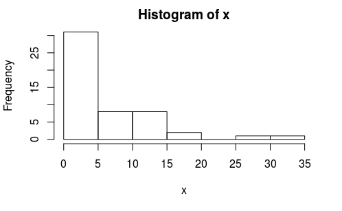

```r
x <- with(murders, population_in_millions/total_gun_murders*100)
hist(x)
```

3. Generate boxplots of the state populations by region.

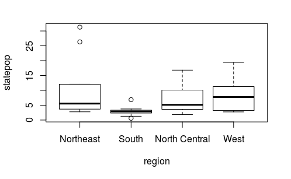

```r
murders$statepop <- with(murders,population_in_millions/total_gun_murders*100)
boxplot(statepop~region, data = murders)
```